# Drug and Alcohol Health Analysis

Deric Liang and David Chen

04/30/2019

In recent times, drug overdoses within the United States have been on the rise, capturing the attention of local and national media. In an attempt to help understand this crisis, we will be attempting to use classical regression models and supervised learning methods to link state health expenditure and census variables to drug and alcohol overdose deaths (more specifically intentional and unintentional self-poisoning deaths). In exploring this relationship, we seek to understand what variables are most influential in predicting overdose rates, directing future investigation into this subject. We also aim to understand the similarities between states, testing to see if the regions designated by the US Census Bureau are reflected within the data.

Data sources can be found in the README.md file.

## Data Wrangling

```r
# Drug Mortality Data
### Remove unnecessary columns and `Total` row
drugmort <-
  drugmort_raw %>%
  na.omit() %>%
  select(-Notes, -`State Code`) %>%
  mutate(Deaths = as.numeric(Deaths)) %>%
  rename(DrugDeaths = Deaths,
         DrugMortalityRate = `Crude Rate`)

# Education Level Data
### Clean headers, select for state data, select relevant columns
educ <-
  educ_raw %>%
  distinct(State, .keep_all = TRUE) %>%
  filter(`FIPS Code` != is.na(`FIPS Code`),
         State != "PR") %>%
  select(`Area name`, `Percent of adults with a bachelor's degree or higher, 2013-17`,
         `Percent of adults completing some college or associate's degree, 2013-17`,
         `Percent of adults with a high school diploma only, 2013-17`,
         `Percent of adults with less than a high school diploma, 2013-17`) %>%
  rename(State = `Area name`,
         PercentBachelor = `Percent of adults with a bachelor's degree or higher, 2013-17`,
         PercentAssoc = `Percent of adults completing some college or associate's degree, 2013-17`,
         PercentHS = `Percent of adults with a high school diploma only, 2013-17`,
         PercentLessHS = `Percent of adults with less than a high school diploma, 2013-17`)

# Health Expenditure Data
### Remove non-state rows, extraneous column
healthexp <-
  healthexp_raw[1:51] %>%
  rename(HealthExpenditure = `2016`, State = STATE) %>%
  mutate(HealthExpenditure = parse_number(HealthExpenditure)) %>%
  select(State, HealthExpenditure)

# Poverty Data
### Clean headers, select for state data, select relevant columns
poverty_raw$State[poverty_raw$State == "Wi"] <- "WI"
poverty <-
  poverty_raw %>%
  distinct(State, .keep_all = TRUE) %>%
  filter(FIPStxt != is.na(FIPStxt)) %>%
  select(Area_Name, POVALL_2017, PCTPOVALL_2017, POV017_2017, PCTPOV017_2017) %>%
  rename(State = Area_Name,
         PovertyCountAll = POVALL_2017,
         PovertyPctAll = PCTPOVALL_2017,
         PovertyCount0_17 = POV017_2017,
         PovertyPctAll0_17 = PCTPOV017_2017) %>%
  mutate(PovertyCountAll = parse_number(PovertyCountAll),
         PovertyCount0_17 = parse_number(PovertyCount0_17))

# Unemployment Data
### Clean headers, select for state data, select relevant columns
unemp_raw$State[unemp_raw$State == "Co"] <- "CO"
unemployment <-
  unemp_raw %>%
  distinct(State, .keep_all = TRUE) %>%
  filter(FIPStxt != is.na(FIPStxt),
         State != "PR") %>%
  select(Area_name, Civilian_labor_force_2016, Unemployed_2016, Unemployment_rate_2016) %>%
  rename(State = Area_name,
         LaborForce = Civilian_labor_force_2016,
         Unemployed = Unemployed_2016,
         UnemploymentRate = Unemployment_rate_2016) %>%
  mutate(LaborForce = parse_number(LaborForce),
         Unemployed = parse_number(Unemployed))
```

```r
# Adding in intentional and unintentional deaths as separate variables
intdeath <-
  int_death %>%
  filter(State != "District of Columbia") %>%
  select(-Notes, -`State Code`) %>%
  mutate(Deaths = as.numeric(Deaths)) %>%
  rename(int_DrugDeaths = Deaths,
         int_DrugMortalityRate = `Crude Rate`) %>%
  # Some values are considered unreliable but we will continue to use them for this analysis
  mutate(int_DrugMortalityRate = parse_number(int_DrugMortalityRate))

unintdeath <-
  unint_death %>%
  filter(State != "District of Columbia") %>%
  select(-Notes, -`State Code`, -`Population`) %>%
  mutate(Deaths = as.numeric(Deaths)) %>%
  rename(unint_DrugDeaths = Deaths,
         unint_DrugMortalityRate = `Crude Rate`)


combined_deaths <-
  left_join(intdeath, unintdeath, by = 'State')


HealthData <-
  left_join(combined_deaths, drugmort, by = c("State", 'Population')) %>%
  left_join(healthexp, by = "State") %>%
  left_join(educ, by = 'State') %>%
  left_join(poverty, by = 'State') %>%
  left_join(unemployment, by = 'State') %>%
  filter(State != "District of Columbia")
```

### Data Wrangling - Regions according to the US Census Bureau:

Sourced from : https://www.businessinsider.com/united-states-regions-new-england-midwest-south-2018-4

1. “The Northeast includes Maine, New Hampshire, Vermont, Massachusetts, Rhode Island, Connecticut, New York, New Jersey, and Pennsylvania.”
2. “[The Midwest] consists of Ohio, Michigan, Indiana, Wisconsin, Illinois, Minnesota, Iowa, Missouri, North Dakota, South Dakota, Nebraska, and Kansas.”
3. “…the South consists of Delaware, Maryland, Virginia, West Virginia, Kentucky, North Carolina, South Carolina, Tennessee, Georgia, Florida, Alabama, Mississippi, Arkansas, Louisiana, Texas, and Oklahoma.”
4. “The West consists of Montana, Idaho, Wyoming, Colorado, New Mexico, Arizona, Utah, Nevada, California, Oregon, Washington, Alaska, and Hawaii.”

```r
# Attaching region to dataset

HealthData_region <-
  HealthData %>%

  # This line identifies the region and creates the variable
  mutate(region = sapply(HealthData$State, FUN = identify_region)) %>%

  # Create a copy of region to unnest and spread
  mutate(region_copy = region) %>%

  # The following code creates dummy variables for region
  unnest(region_copy) %>%
  mutate(new = 1) %>%
  spread(region_copy, new, fill = 0)
```

Now that we’ve finally finished consolidating all the datasets – it’s time to start doing some basic EDA! First, we want to examine the relationship between intentional and unintentional drug mortality rates. As expected, for the raw counts there appears to be a fairly strong relationship, with unintentional deaths far higher than intentional. However, much to our surprise, there doesn’t appear to be a strong relationship between the Crude rates (per 100,000).

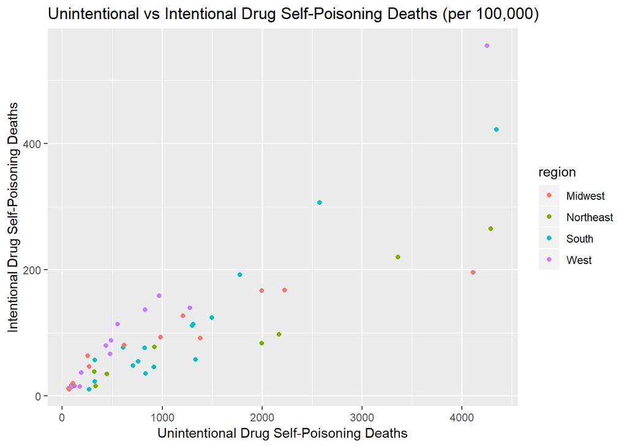

```r
#EDA

ggplot(HealthData_region, aes(x = unint_DrugDeaths,
                              y = int_DrugDeaths, color = region)) +
  geom_point() +
  labs(x = 'Unintentional Drug Self-Poisoning Deaths',
       y = 'Intentional Drug Self-Poisoning Deaths',
       title = 'Unintentional vs Intentional Drug Self-Poisoning Deaths (per 100,000)')
```

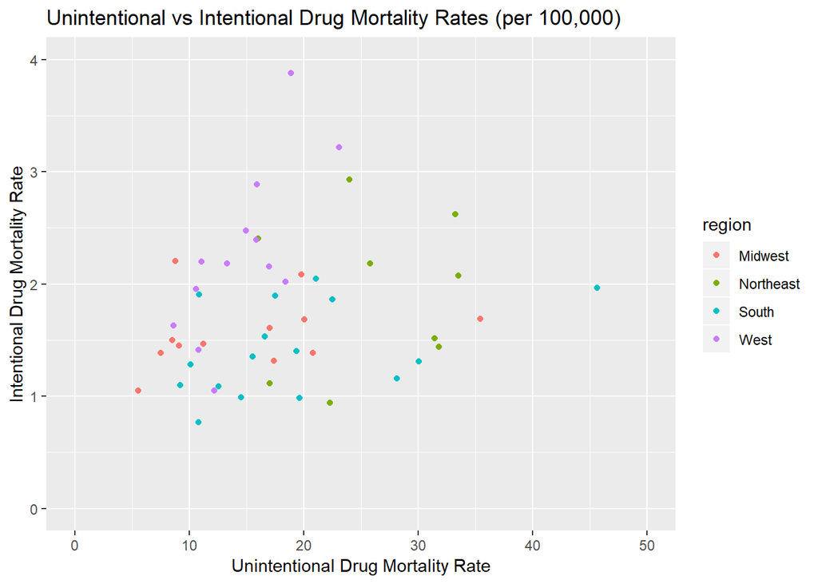

```r
ggplot(HealthData_region, aes(x = unint_DrugMortalityRate,
                              y = int_DrugMortalityRate, color = region)) +
  geom_point() +
  labs(x = 'Unintentional Drug Mortality Rate',
       y = 'Intentional Drug Mortality Rate',
       title = 'Unintentional vs Intentional Drug Mortality Rates (per 100,000)') +
  xlim(0, 50) +
  ylim(0, 4)
```

We want to look further to see if there is any similarities between the regions. By creating a faceted graph, we can directly compare the regions. We can immediately see that the Western region appears to be unique with intentional drug mortality rates peaking with low unintentional drug mortality rates. The remaining three regions appear to be similar, although there definitely appears to be some differentiation.

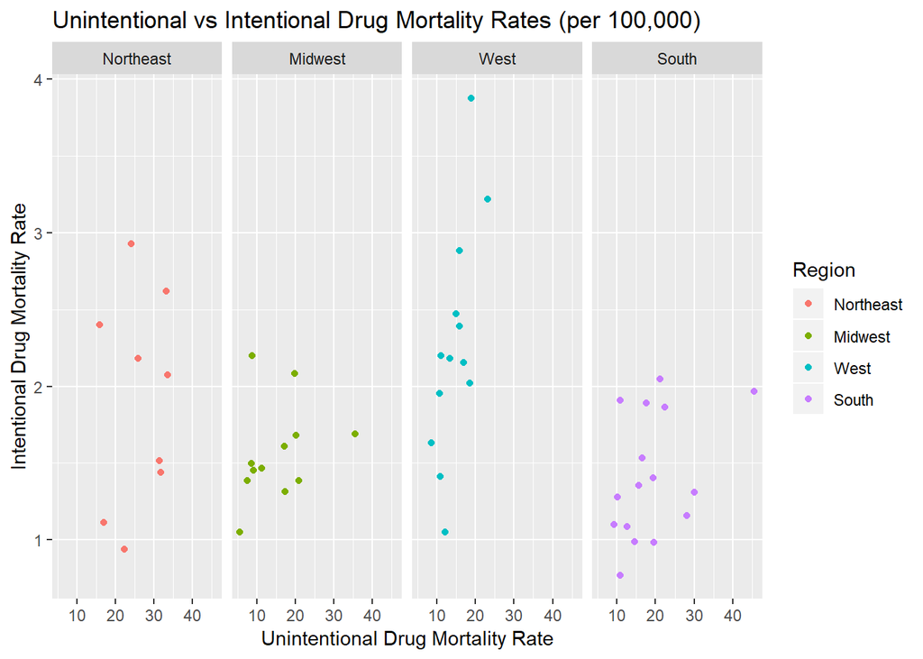

```r
temp <- HealthData_region
temp$Region <- factor(temp$region, levels = c('Northeast', 'Midwest', 'West', 'South'))

ggplot(temp, aes(x = unint_DrugMortalityRate,
                              y = int_DrugMortalityRate, color = Region)) +
  geom_point() +
  labs(x = 'Unintentional Drug Mortality Rate',
       y = 'Intentional Drug Mortality Rate',
       title = 'Unintentional vs Intentional Drug Mortality Rates (per 100,000)') +
  facet_wrap(~Region, nrow = 1)
```

Now that we’ve processed the individual rates, perhaps it’s time to look more specifically at the states. By ordering the combined rates (intentional + unintentional) we can see which states are more affected than others. For example, we can clearly see that West Virginia is an outlier. The regions appear to be fairly well mixed as well.

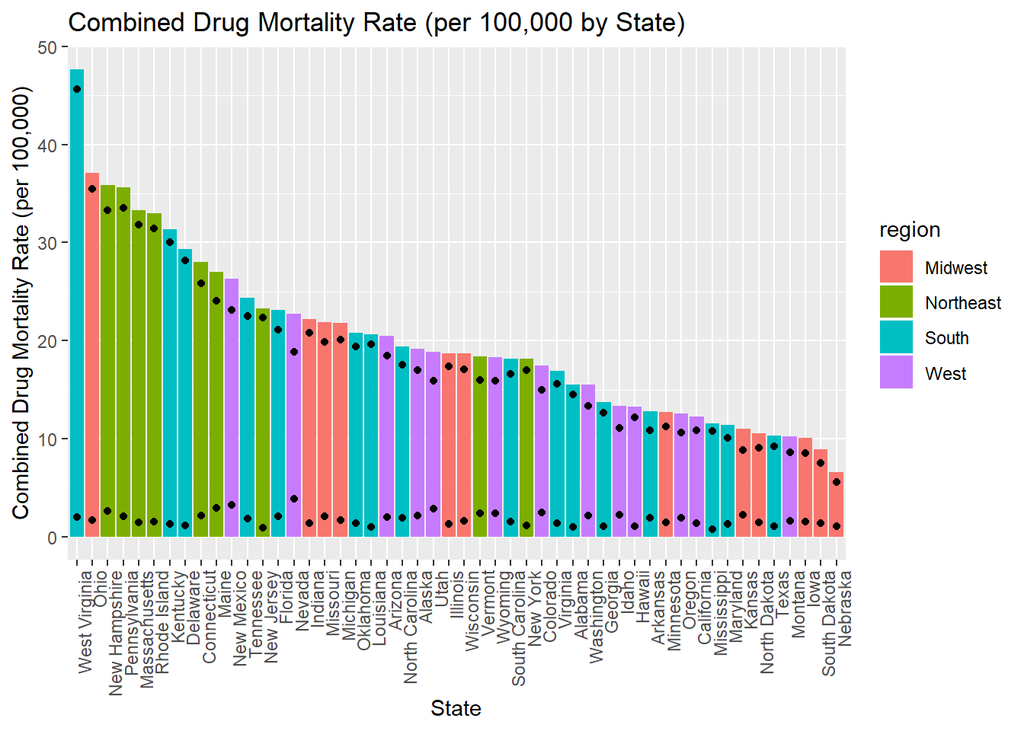

```r
testing <- HealthData_region$State
p <-
  ggplot(HealthData_region, aes(x = reorder(State, -DrugMortalityRate),
                                y = DrugMortalityRate)) +
  geom_col(data = HealthData_region, aes(fill = region)) +
  theme(axis.text.x = element_text(angle = 90, hjust = 1)) +
  labs(y = 'Combined Drug Mortality Rate (per 100,000)',
       x = 'State', title = 'Combined Drug Mortality Rate (per 100,000 by State)')

p +
  geom_point(data = unintdeath, aes(x = State, y = unint_DrugMortalityRate)) +
  geom_point(data = intdeath, aes(x = State, y = int_DrugMortalityRate))
```

Next we want to examine the influence of per capita Health Expenditures on the overall Drug Mortality rate. By subsetting into regions, we can immediately see that there is no immediate linear trend. We will need to investigate further to see what factors influence the various rates.

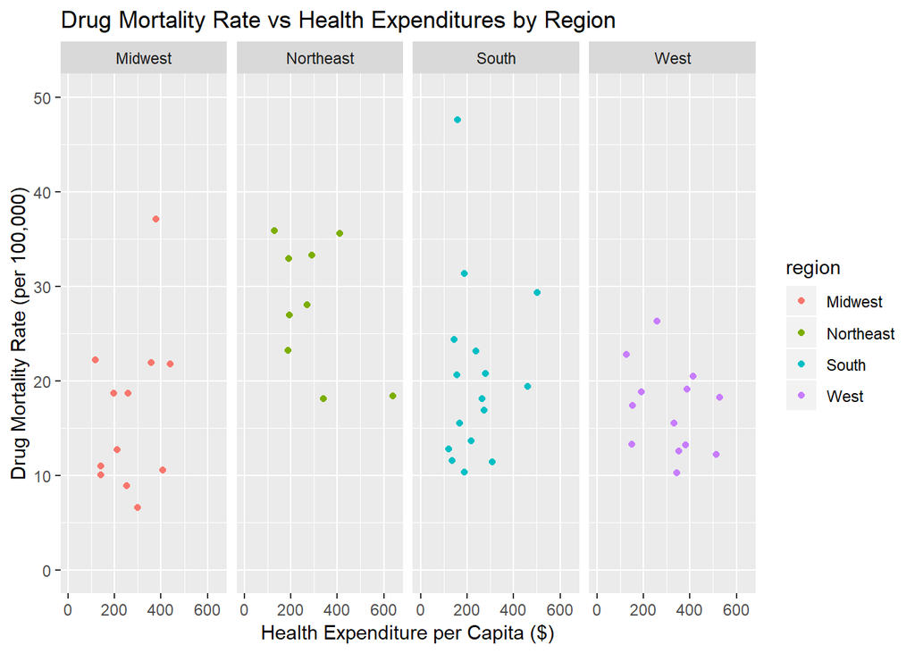

```r
ggplot(HealthData_region, aes(x = HealthExpenditure, y = DrugMortalityRate,  color = region)) +
  geom_point() +
  xlim(0, 650) +
  ylim(0, 50) +
  facet_wrap(~region, nrow = 1) +
  labs(x = 'Health Expenditure per Capita ($)',
       y = 'Drug Mortality Rate (per 100,000)',
       title = 'Drug Mortality Rate vs Health Expenditures by Region')
```

## Regression Models/Supervised Learning

We define the formula that indicates the relationship we want to explore in this analysis. This indicates that we seek to explore how health expenditure, education level, poverty level, and unemployment rate affect drug mortality rate.

```r
form <-
  DrugMortalityRate ~ HealthExpenditure + PercentBachelor + PovertyPctAll + UnemploymentRate
```

### Null Model

The first task is to set up a null model, in order to have a baselline to compare the rest of our models to. We certainly do not want any of our models to perform worse than the null model.

```r
null_mod <-
  lm(DrugMortalityRate ~ 1, data = HealthData_region)
summary(null_mod)
```

```
##
## Call:
## lm(formula = DrugMortalityRate ~ 1, data = HealthData_region)
##
## Residuals:
##     Min      1Q  Median      3Q     Max
## -13.392  -7.104  -1.317   3.216  27.622
##
## Coefficients:
##             Estimate Std. Error t value Pr(>|t|)
## (Intercept)   19.999      1.222   16.37   <2e-16 ***
## ---
## Signif. codes:  0 '***' 0.001 '**' 0.01 '*' 0.05 '.' 0.1 ' ' 1
##
## Residual standard error: 8.638 on 49 degrees of freedom
```

```r
nullrsq <-
  1 - sum((null_mod$residuals)^2) / sum((HealthData_region$DrugMortalityRate - mean(HealthData_region$DrugMortalityRate))^2)
nullrsq
```

```
## [1] 1.110223e-16
```

### Regression

The common and most interpretable method used to explore relationships between variables is regression techniques, so we perform this before building other models. To begin, we fit the full linear regression model with all the regressors previously indicated.

```r
fullhealth_lm <-
  lm(form, data = HealthData_region)
summary(fullhealth_lm)
```

```
##
## Call:
## lm(formula = form, data = HealthData_region)
##
## Residuals:
##      Min       1Q   Median       3Q      Max
## -11.2358  -6.9459  -0.9575   2.6628  24.0221
##
## Coefficients:
##                   Estimate Std. Error t value Pr(>|t|)
## (Intercept)        4.99785   18.64591   0.268   0.7899
## HealthExpenditure -0.00498    0.01030  -0.483   0.6312
## PercentBachelor    0.10645    0.37522   0.284   0.7780
## PovertyPctAll     -0.08275    0.80423  -0.103   0.9185
## UnemploymentRate   3.08214    1.61065   1.914   0.0622 .
## ---
## Signif. codes:  0 '***' 0.001 '**' 0.01 '*' 0.05 '.' 0.1 ' ' 1
##
## Residual standard error: 8.636 on 44 degrees of freedom
##   (1 observation deleted due to missingness)
## Multiple R-squared:  0.1022, Adjusted R-squared:  0.0206
## F-statistic: 1.252 on 4 and 44 DF,  p-value: 0.303
```

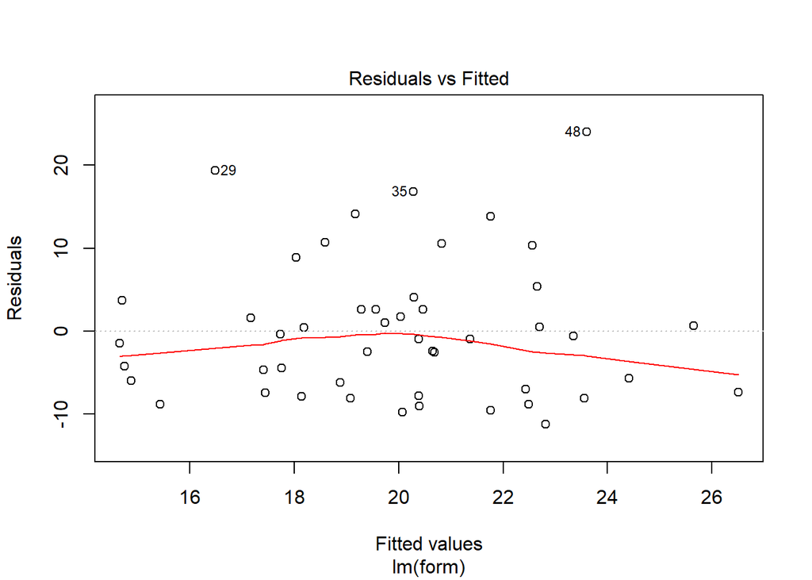

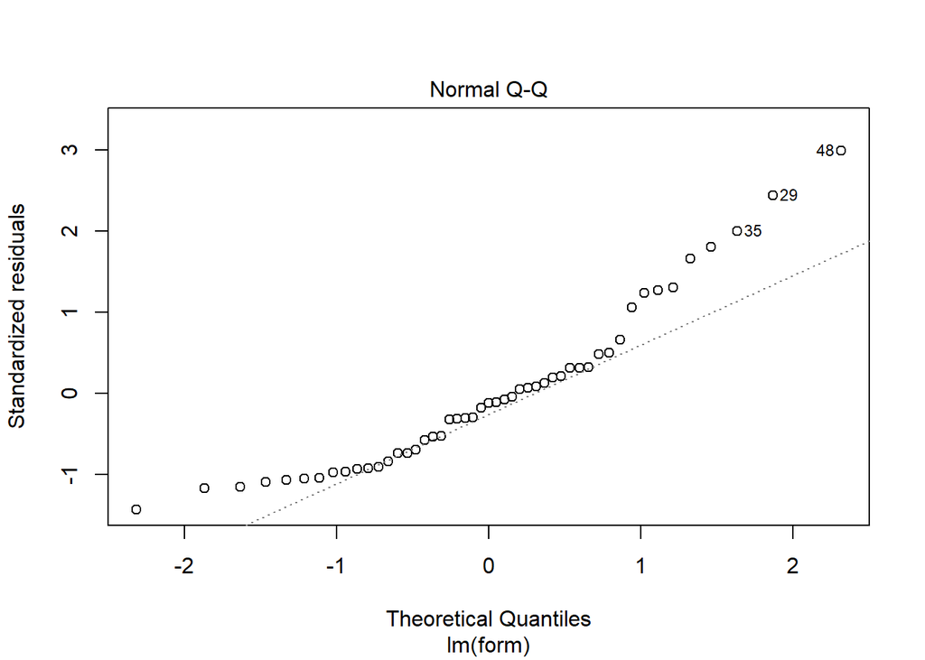

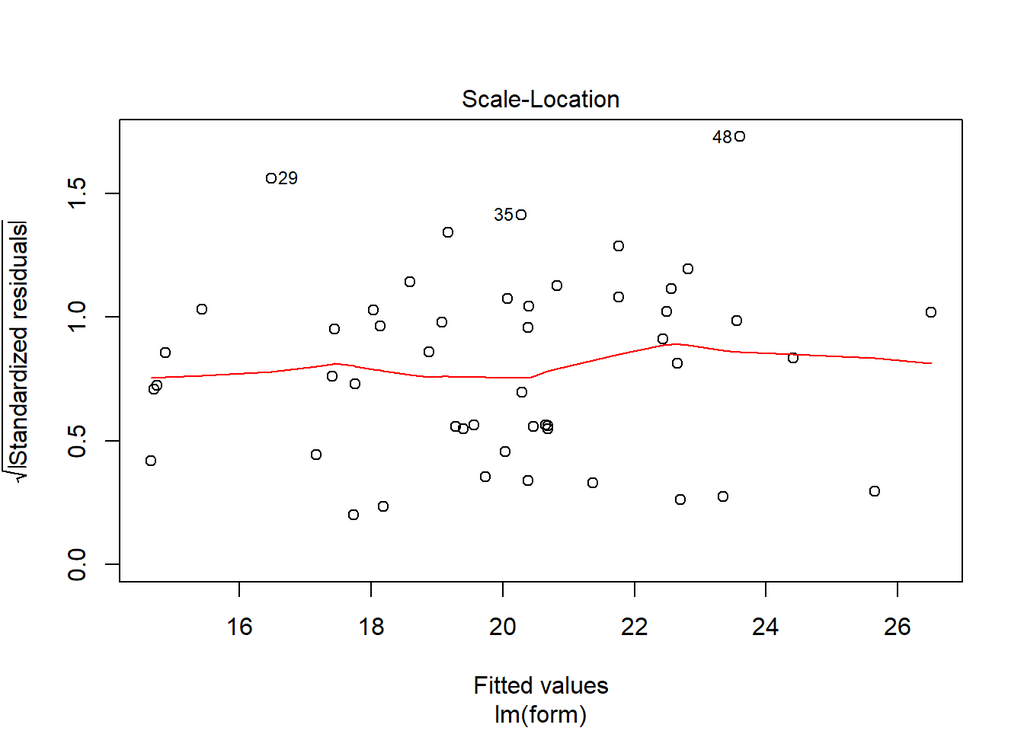

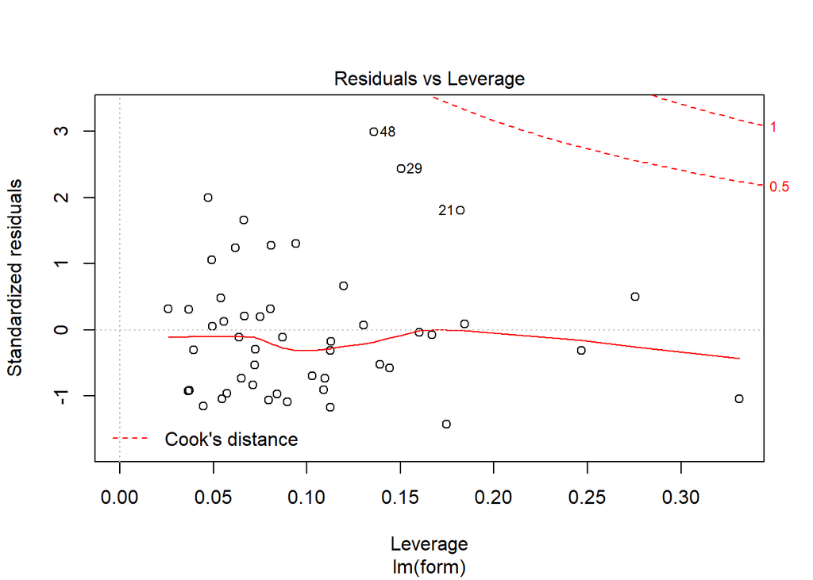

```r
plot(fullhealth_lm)
```

This fitted model is not good; none of the regressors are significant. Therefore, we would like to create subsets to compare the BIC of different models that can be built with these regressors. The lowest BIC indicates the best fit.

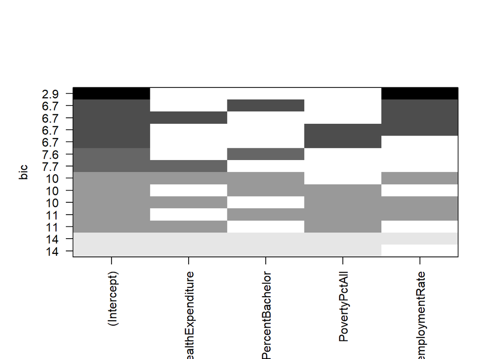

```r
subsets <-
  regsubsets(form, data = HealthData_region, nbest = 5)
plot(subsets)
```

The model with just the unemployment rate regressor is the best. Therefore, we want to fit a regression model with only that regressor. Since this is a simple linear regression problem, it is useful to first visualize the relationship between drug mortality rate and unemployment rate.

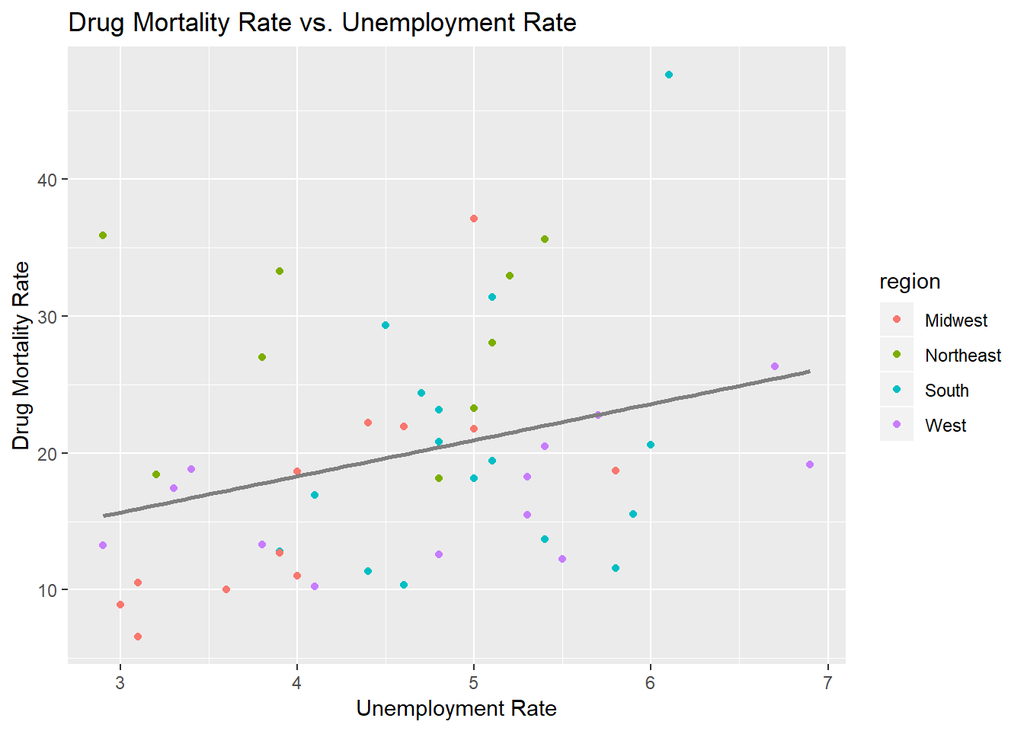

```r
HealthData_region %>%
  ggplot(aes(x = UnemploymentRate, y = DrugMortalityRate)) +
  geom_point(aes(color = region)) +
  stat_smooth(color = "grey50", method = lm, se = 0) +
  xlab("Unemployment Rate") +
  ylab("Drug Mortality Rate") +
  labs(title = "Drug Mortality Rate vs. Unemployment Rate")
```

```r
red_lm <-
  lm(DrugMortalityRate ~ UnemploymentRate, data = HealthData_region)
summary(red_lm)
```

```
##
## Call:
## lm(formula = DrugMortalityRate ~ UnemploymentRate, data = HealthData_region)
##
## Residuals:
##     Min      1Q  Median      3Q     Max
## -11.480  -6.636  -1.723   2.611  23.772
##
## Coefficients:
##                  Estimate Std. Error t value Pr(>|t|)
## (Intercept)         7.740      5.682   1.362   0.1795
## UnemploymentRate    2.641      1.198   2.205   0.0323 *
## ---
## Signif. codes:  0 '***' 0.001 '**' 0.01 '*' 0.05 '.' 0.1 ' ' 1
##
## Residual standard error: 8.316 on 48 degrees of freedom
## Multiple R-squared:  0.09199,    Adjusted R-squared:  0.07308
## F-statistic: 4.863 on 1 and 48 DF,  p-value: 0.03226
```

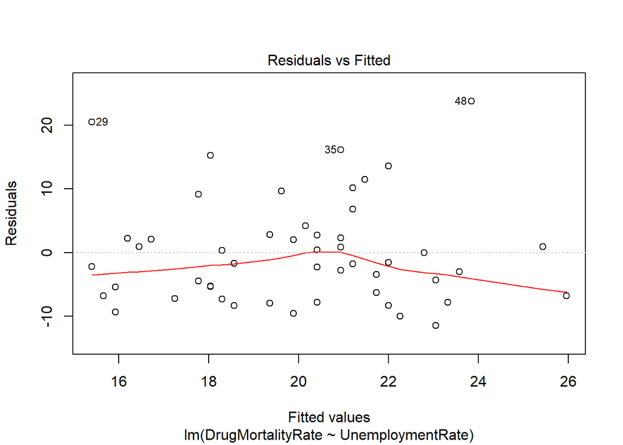

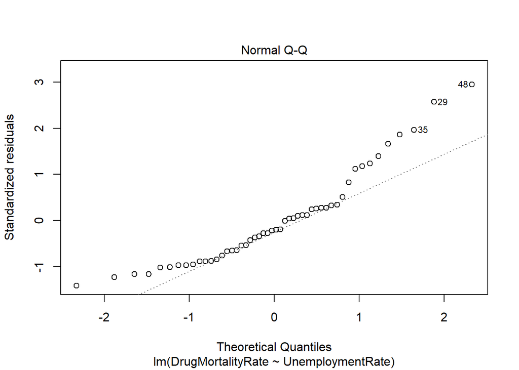

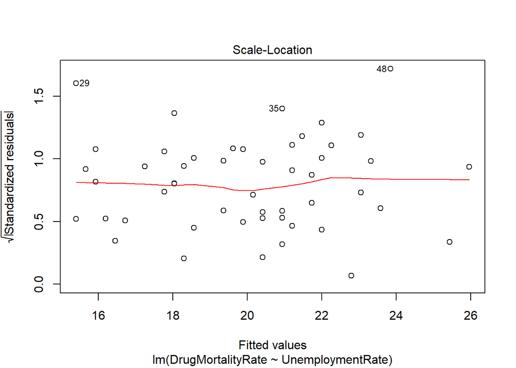

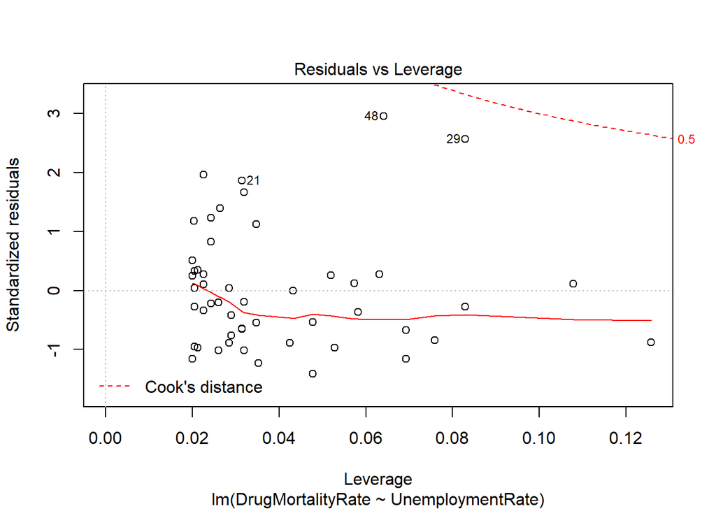

```r
plot(red_lm)
```

### Supervised Learning

We want to explore other modeling methods which could help us predict Drug Mortality Rate, beyond classical regression models.

*Regression Tree*

We first fit a regression tree, which will help us understand how the drug mortality rate will change based off of different grouped values of our predictors.

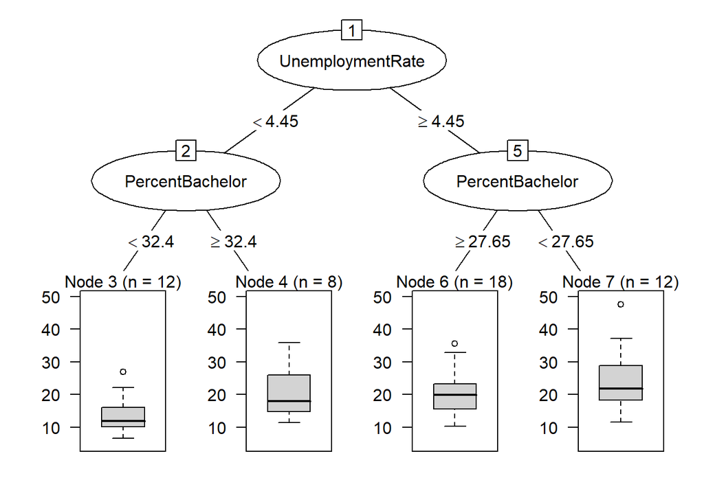

```r
regtree <-
  rpart(form, data = HealthData_region)
plot(as.party(regtree))
```

The regression tree shows that the education level (the percent of people who have a Bachelor’s degree) is also significant in predicting Drug Mortality Rate, in addition to Unemployment Rate. An unemployment rate greater than or equal to 4.45% shows higher drug mortality, and within that group, states with less than 27.65% of people having a Bachelors shows higher drug mortality than states with more than 27.65% of people having a Bachelors. For states with an unemployment rate of less than 4.45%, states with more than 32.4% of people having a Bachelors has a higher drug mortality than states with less than 32.4% of people having a Bachelors. This generally shows that unemployment rate is more important than the education level in predicting drug mortality rate.

```r
# define training control
train_control <-
  trainControl(method = "cv", number = 10)
# train the model
regtreecv <-
  form %>%
  train(data = na.omit(HealthData_region), trControl = train_control, method = "rpart")
# summarize results
regtreecv
```

```
## CART
##
## 49 samples
##  4 predictor
##
## No pre-processing
## Resampling: Cross-Validated (10 fold)
## Summary of sample sizes: 43, 43, 43, 46, 45, 43, ...
## Resampling results across tuning parameters:
##
##   cp          RMSE      Rsquared   MAE
##   0.02985391  9.096318  0.2530172  7.482665
##   0.06236531  8.822621  0.3412258  7.456256
##   0.11452540  9.176424  0.3592473  7.701120
##
## RMSE was used to select the optimal model using the smallest value.
## The final value used for the model was cp = 0.06236531.
```

*Random Forest*

Next, we would like to fit a random forest model. This will give us an idea of the most to least important predictors in predicting drug mortality rate.

```r
# train the model
forestcv <-
  form %>%
  train(data = na.omit(HealthData_region), trControl = train_control, method = "rf")
# summarize results
forestcv
```

```
## Random Forest
##
## 49 samples
##  4 predictor
##
## No pre-processing
## Resampling: Cross-Validated (10 fold)
## Summary of sample sizes: 45, 44, 43, 43, 44, 44, ...
## Resampling results across tuning parameters:
##
##   mtry  RMSE      Rsquared   MAE
##   2     9.555660  0.2578753  7.895193
##   3     9.617666  0.2176216  7.965614
##   4     9.639517  0.2300918  7.942663
##
## RMSE was used to select the optimal model using the smallest value.
## The final value used for the model was mtry = 2.
```

```r
trainforest <-
  randomForest(form, data = HealthData_region, ntree = 200,
               mtry = 2, na.action = na.omit)
importance(trainforest) %>%
  as.data.frame() %>%
  rownames_to_column() %>%
  arrange(desc(IncNodePurity))
```

```
##             rowname IncNodePurity
## 1   PercentBachelor      961.3863
## 2  UnemploymentRate      878.2969
## 3     PovertyPctAll      707.7052
## 4 HealthExpenditure      587.5964
```

### Supervised Learning Summary

Generally, we learned that the unemployment rate and education level (the percent of people with a Bachelors) are the biggest predictors in drug mortality rate, consistent across several models. The percent of people in poverty and health expenditure are not as significant in predicting drug mortality rate.

## Unsupervised Learning

First we wanted to conduct a PCA to see how much the dataset could be reduced. We first removed categorical variables and dummy variables (the region variables), as well as variables that could be calculated through the other variables (Most notably DrugDeaths and DrugMortalityRate). Then, as Population and crude rates are included, direct values such as number of Unemployed are removed.

```r
HealthData_pca <-
  HealthData_region %>%
  select(-c('State', 'region', 'DrugDeaths', 'DrugMortalityRate', 'Midwest', 'Northeast',
            'South', 'West', 'PercentAssoc', 'Unemployed', 'PovertyCountAll')) %>%
  na.omit() %>%
  prcomp(scale = TRUE)
```

We then examine the two top PCA to see how they are composed.

```r
(-1) * HealthData_pca$rotation[, 1:2] %>% round(2)
```

```
##                           PC1   PC2
## int_DrugDeaths          -0.37  0.20
## Population              -0.39  0.21
## int_DrugMortalityRate    0.11 -0.03
## unint_DrugDeaths        -0.35  0.13
## unint_DrugMortalityRate -0.04 -0.17
## HealthExpenditure       -0.03  0.18
## PercentBachelor          0.08  0.43
## PercentHS                0.03 -0.37
## PercentLessHS           -0.33 -0.23
## PovertyPctAll           -0.22 -0.42
## PovertyCount0_17        -0.40  0.15
## PovertyPctAll0_17       -0.25 -0.40
## LaborForce              -0.38  0.22
## UnemploymentRate        -0.22 -0.24
```

Plotting the states and regions by the two top PCA components we can see that there appears to be a central cluster of most states before it forms “wings” on both ends. We can also immediately see that California and West Virginia seem to be two unique states that can be examined further.

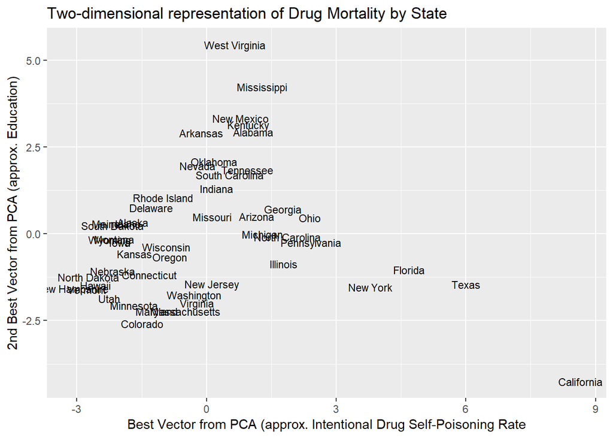

```r
# Louisiana is missing values so they are omitted.
names <- na.omit(HealthData_region)
Region <- names$region

HealthData_pca$x %>%
  as.data.frame() %>%
  rownames_to_column() %>%
  ggplot(aes(x = PC1, y = PC2)) +
  geom_text(aes(label = names$State), size = 3) +
  xlab("Best Vector from PCA (approx. Intentional Drug Self-Poisoning Rate") +
  ylab("2nd Best Vector from PCA (approx. Education)") +
  ggtitle("Two-dimensional representation of Drug Mortality by State")
```

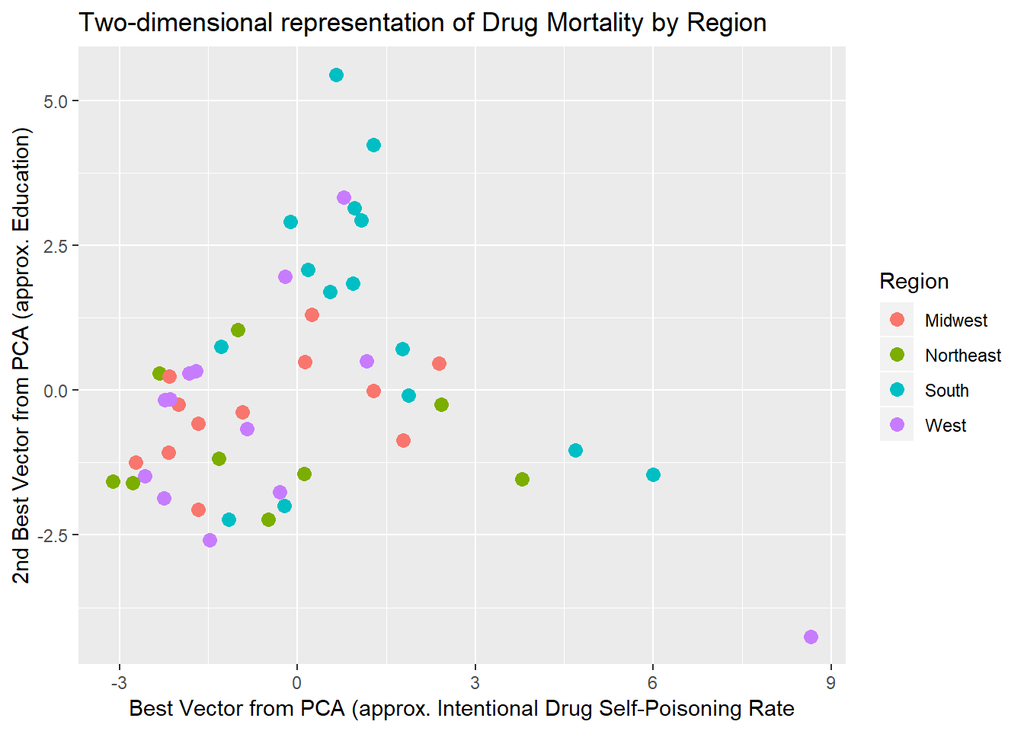

```r
HealthData_pca$x %>%
  as.data.frame() %>%
  ggplot(aes(x = PC1, y = PC2)) +
  geom_point(aes(color = Region), size = 3) +
  xlab("Best Vector from PCA (approx. Intentional Drug Self-Poisoning Rate") +
  ylab("2nd Best Vector from PCA (approx. Education)") +
  ggtitle("Two-dimensional representation of Drug Mortality by Region")
```

For the sake of understanding our PCA analysis further we create the scree plot and cumulative PVE plot. Here we can see that the first two PCA components immediately account for a majority of the variation in the data, making our previous analysis a fairly strong representation of the data.

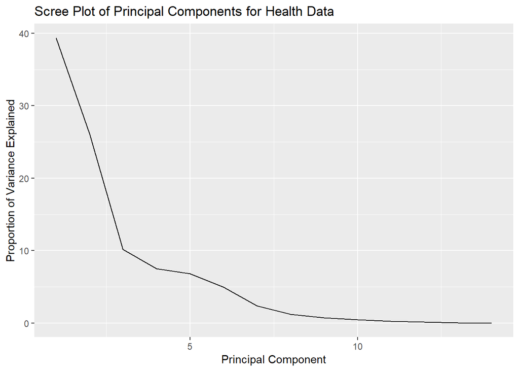

```r
HealthData_pve <-
  data.frame(sd = HealthData_pca$sdev) %>%
  rownames_to_column() %>%
  mutate(rowname = parse_number(rowname),
         totalVar = sum(HealthData_pca$sdev^2),
         pve = 100 * sd^2 / totalVar,
         cusum = cumsum(pve))

# scree plot
HealthData_pve %>%
  ggplot(aes(x = rowname, y = pve)) +
  geom_line(type = 3) +
  xlab("Principal Component") +
  ylab("Proportion of Variance Explained") +
  ggtitle("Scree Plot of Principal Components for Health Data")
```

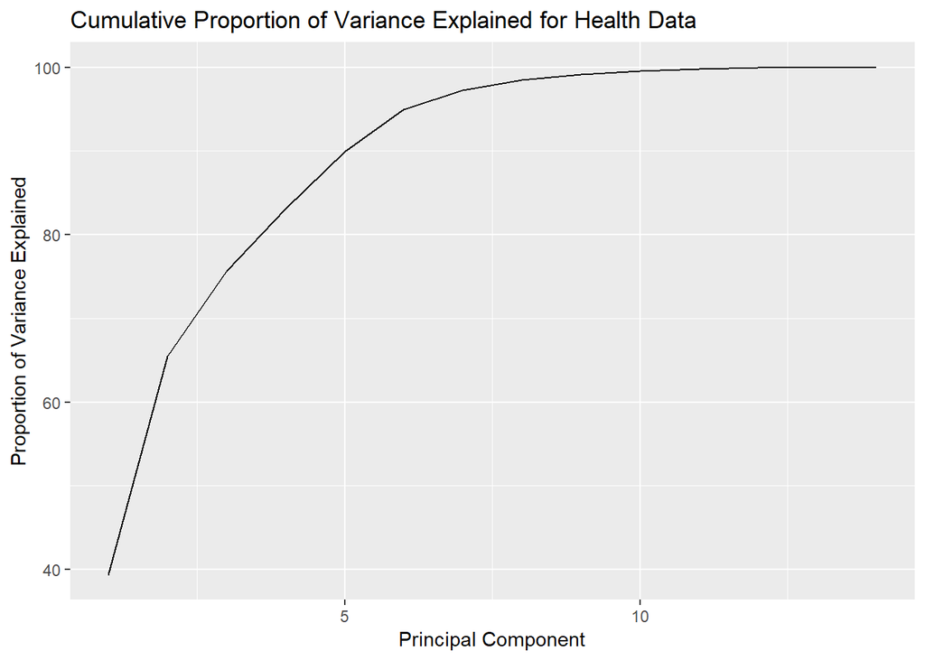

```r
# cumulative PVE plot
HealthData_pve %>%
  ggplot(aes(x = rowname, y = cusum)) +
  geom_line(type = 3) +
  xlab("Principal Component") +
  ylab("Proportion of Variance Explained") +
  ggtitle("Cumulative Proportion of Variance Explained for Health Data")
```

Having conducted the PCA analysis, we now want to move on to examine the different clustering techniques and see if the Census Bureau’s designation of regions is reflected in our data. If we recall from the previous data wrangling, the US Census Bureau classifies US states into four regions: South, Northeast, Midwest, and West.

```r
HD_std <-
  HealthData_region %>%
  select(c(int_DrugMortalityRate, unint_DrugMortalityRate, HealthExpenditure)) %>%
  na.omit() %>%
  scale() %>%
  as.data.frame()
```

By creating a Dendogram we can see the varying amounts of differentiation each state has from the next. We can immediately see 2-3 distinct groups, eliciting us to investigate further into the attributes of each state.

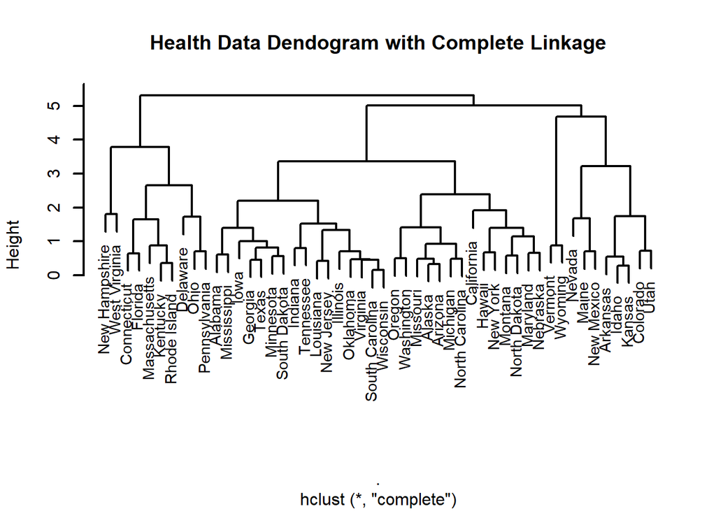

```r
HD_dist <- dist(HD_std)

HD_dendo <-
  HD_dist %>%
  hclust(method = "complete")

HD_dendo %>%
  plot(cex = 0.9, labels = HealthData_region$State, lwd = 2,
       main = "Health Data Dendogram with Complete Linkage")
```

We can also draw a line to mark the cutoff for the first 4 clusters, following our attempts to identify representation of the Census designated regions.

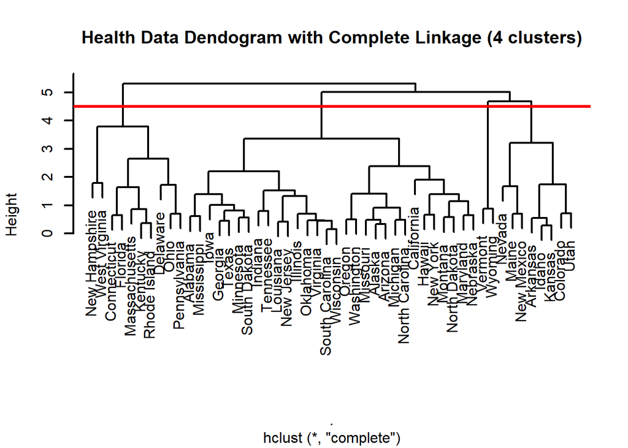

```r
HD_dendo %>%
  plot(labels = HealthData_region$State, lwd = 2,
       main = "Health Data Dendogram with Complete Linkage (4 clusters)") %>%
  abline(h = 4.5, col = "red", lwd = 3)
```

```r
HD_dendoClusters <- cutree(tree = HD_dendo, k = 4)
```

After creating the Dendogram, we also want to performing a k-means Clustering with 4 clusters to see if we will see similar results. Assuming all goes according to intuition, these two methods should result in extremely similar clusters.

```r
set.seed(14)

HD_kmean <-
  HD_std %>%
  kmeans(centers = 4, nstart = 20)

HD_kmeanClusters <- HD_kmean$cluster
```

Let’s now compare and see if the two clustering methods matched:

```r
mosaic::tally(HD_dendoClusters ~ HD_kmeanClusters)
```

```
##                 HD_kmeanClusters
## HD_dendoClusters  1  2  3  4
##                1  1 10 19  0
##                2  0  0  1  7
##                3  9  1  0  0
##                4  0  2  0  0
```

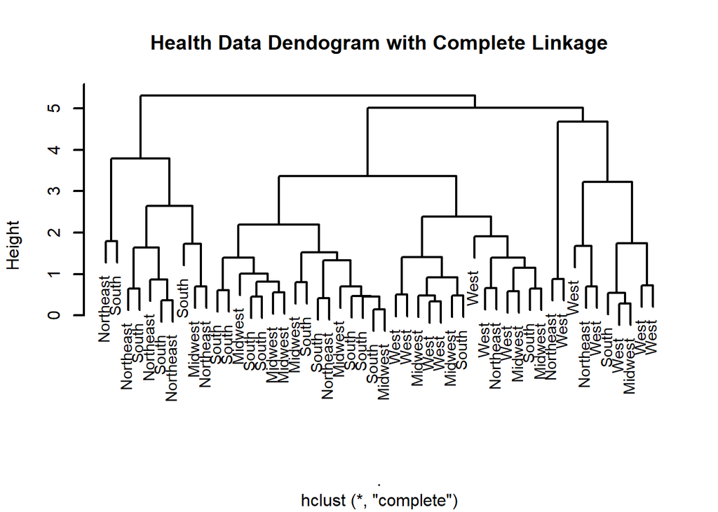

```r
HD_dendo %>%
  plot(cex = 0.9, labels = HealthData_region$region, lwd = 2,
       main = "Health Data Dendogram with Complete Linkage")
```

## Conclusions

Entering this project we wanted to develop a deeper understanding of what variables are influential in predicting drug and alcohol overdose deaths, as well as any potential differentiation between states. Through the use of supervised and unsupervised learning techniques we leave with a basic picture of the current drug and alcohol overdose situation, however much more analysis is needed to truly understand the epidemic.

In consideration of limitations, in the data source some of the states had missing data, resulting in the crude rates being marked as unreliable. We also did not account for changes over time, thus failing to account for the influence of health expenditures on overdose rates.

Moving forward, there is room for much more analysis. Firstly, this data can be processed over time, examining how drug overdose rates have changed over the past few years. By isolating Health Expenditures and breaking down the spending further, we can develop a much stronger understanding of how spending relates to drug overdose rates. We can also add more state level variables such as urbanization rates, pharmaceutical spending, and incarceration rates to try and develop a stronger model. With enough data collection, it could be possible to develop a time series model to begin predicting drug overdose rates and what predictors are the most important.

With drug overdose rates seemingly increasing each year, much more analysis is required to truly understand this rising epidemic. While this report won’t be the one to change the tide, we hope that it has helped demonstrate the complexity of the issue, potentially even challenging the reader to explore the relationships missed here.